# IE360 Homework1

Hatice Serra Hakyemez

09/04/2022

# Introduction

Economic variables are variables of economy collected in a country. There can be correlation between various different economic variables, and they usually show a pattern over time. Therefore studying these variables is an excellent way to learn more about time series analysis and understand how real life trends and dependencies work.

In this study, several economic variables and their relationships are analyzed, in order to find an answer to and draw conclusions about the question: “What is the relationship between price indices, exchange rates and bank loan amounts in the economy of Turkey over the years 2017-2021?”

# Visualization of Data

## Time Series Plots

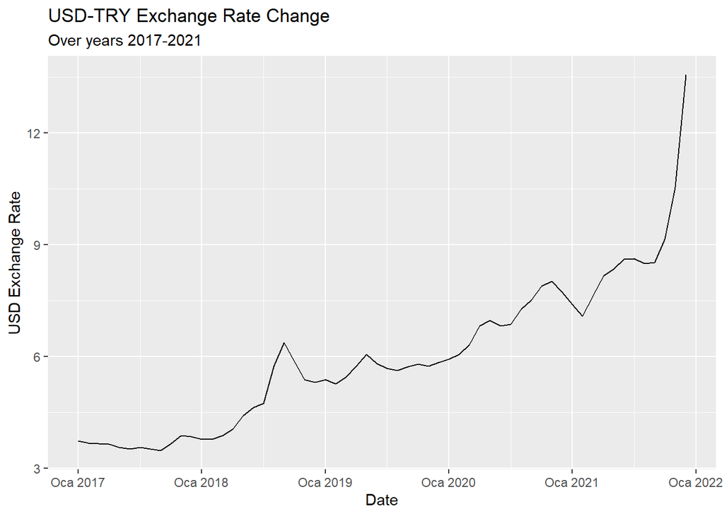

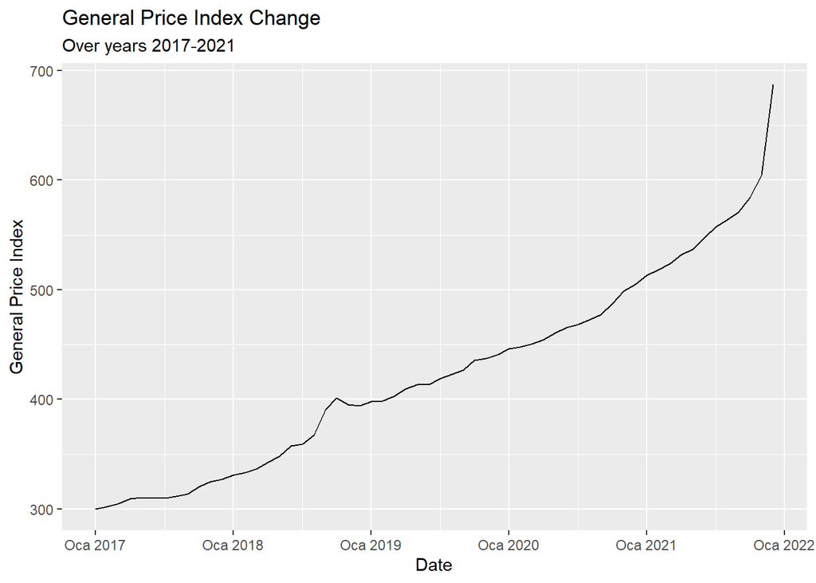

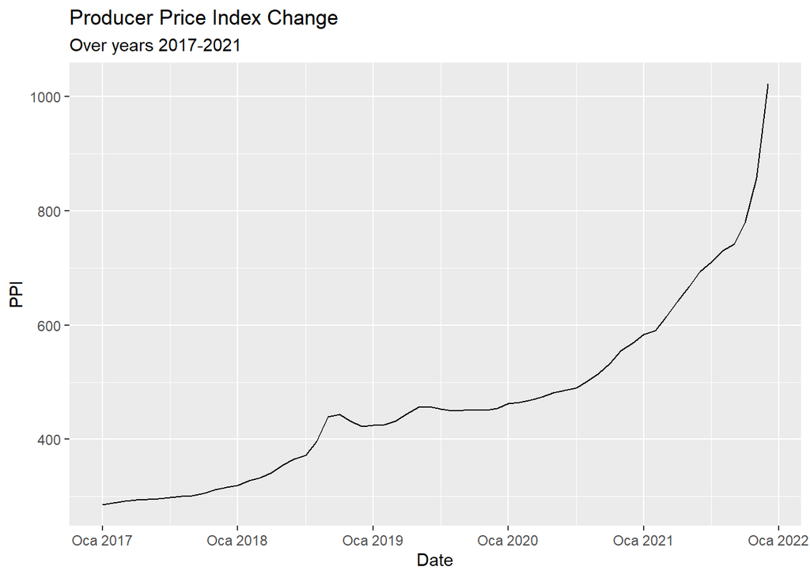

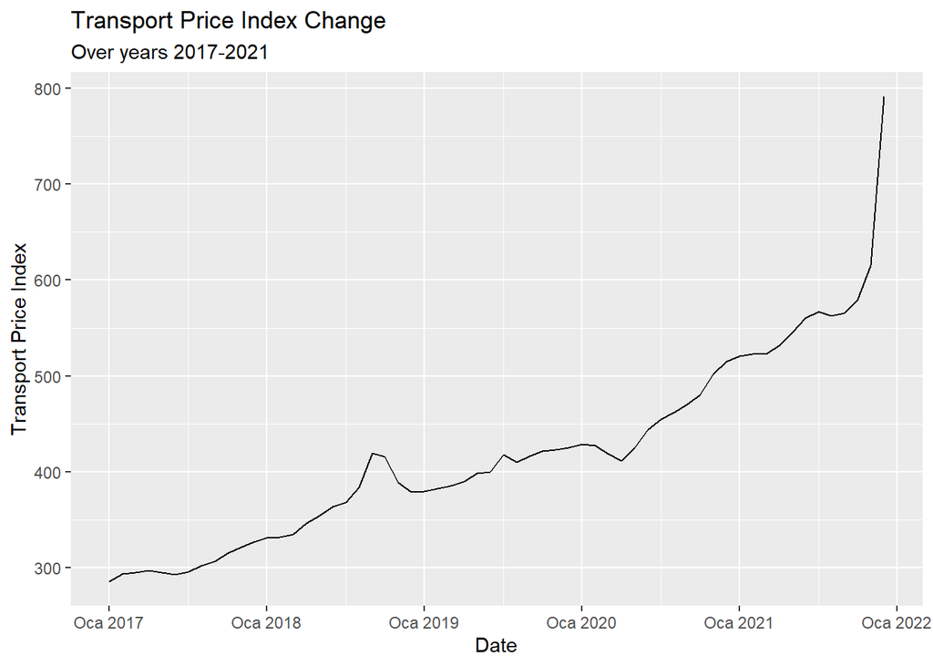

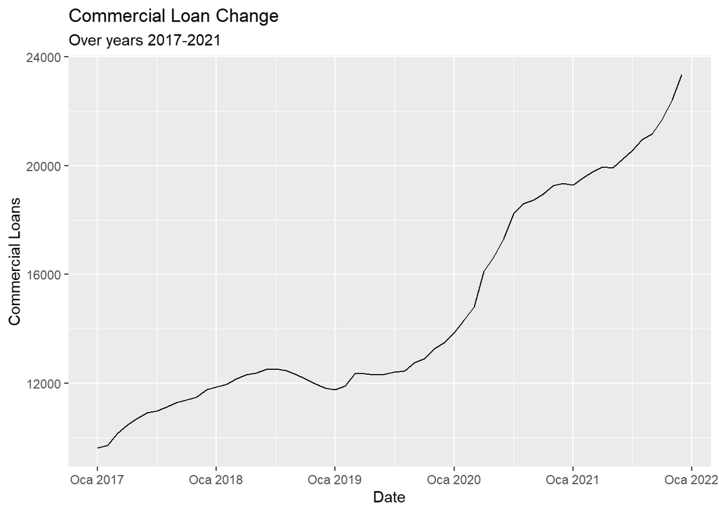

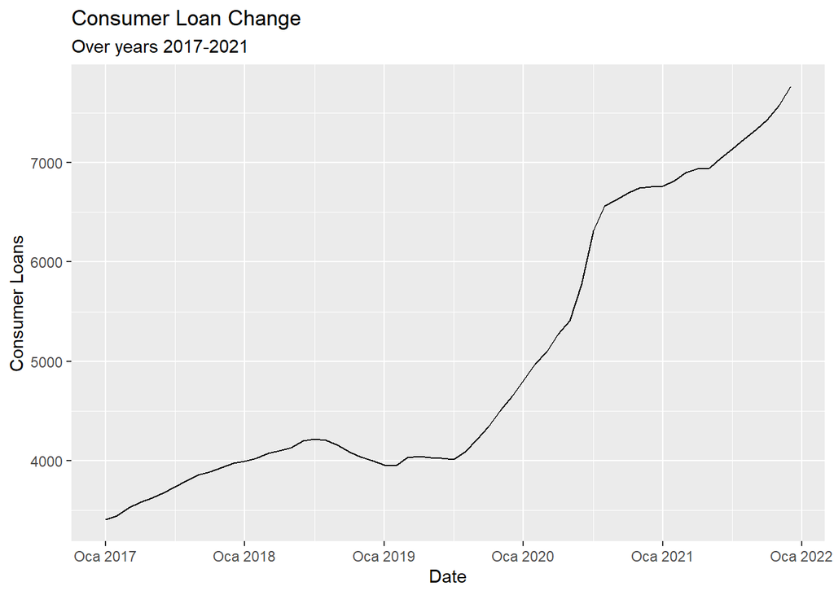

# Selecting Data

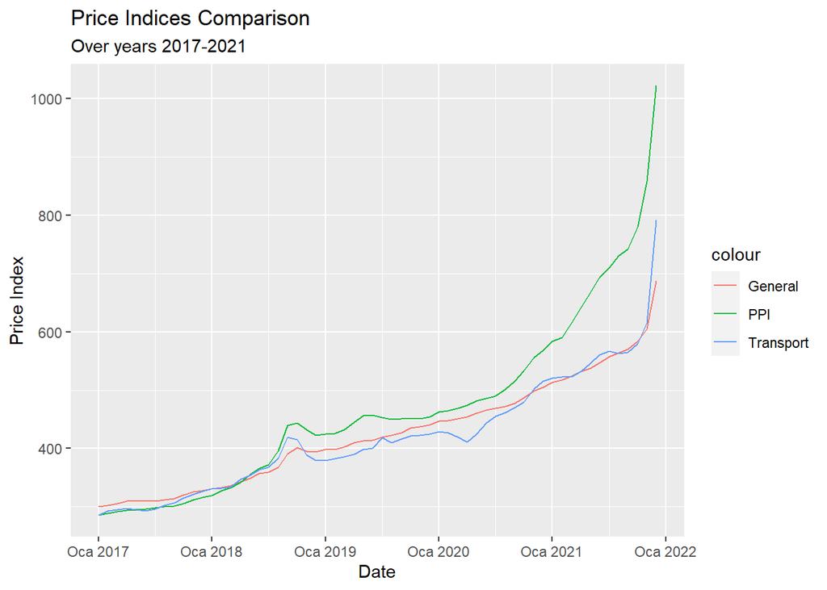

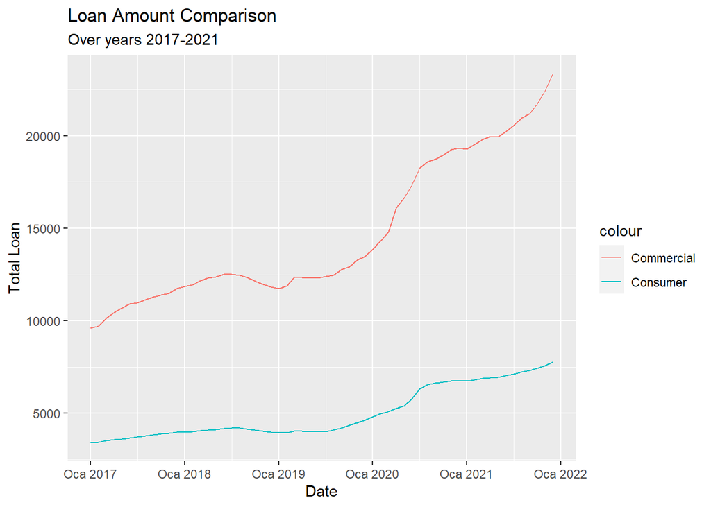

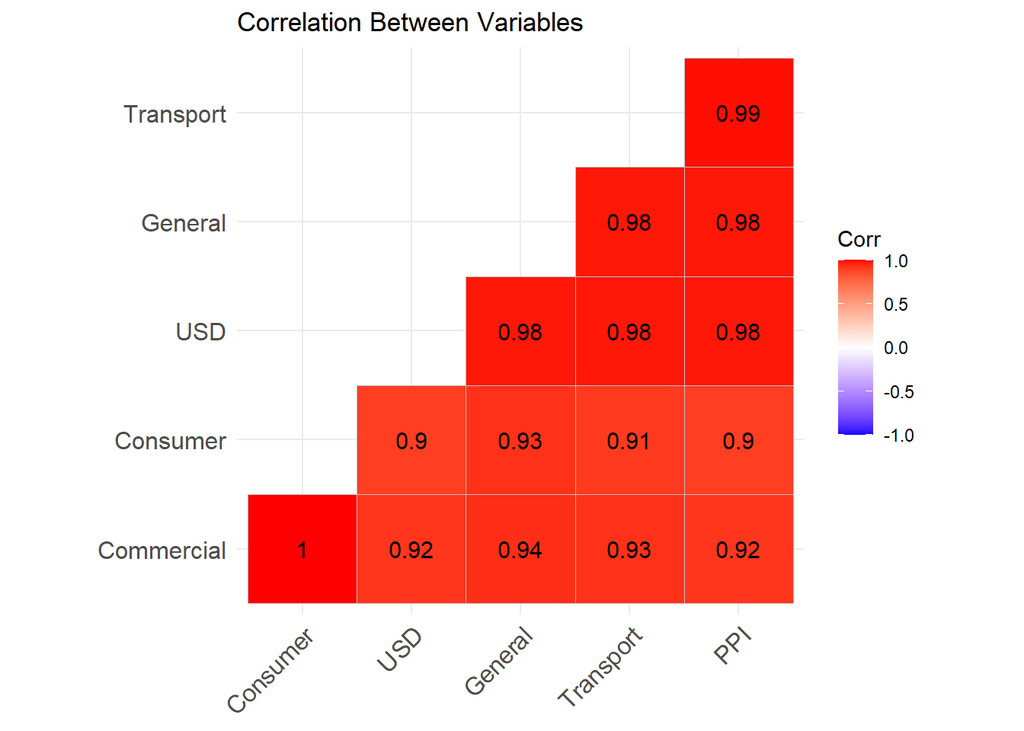

It can be seen from the price index comparison graph that, over the years all three price indices showed a very similar pattern of growth. Since general price index consists of a wider range of products and services, it is sufficient enough to use this variable in the further analysis.

Looking at the loan amount comparison graph, one can say there is a similar trend.

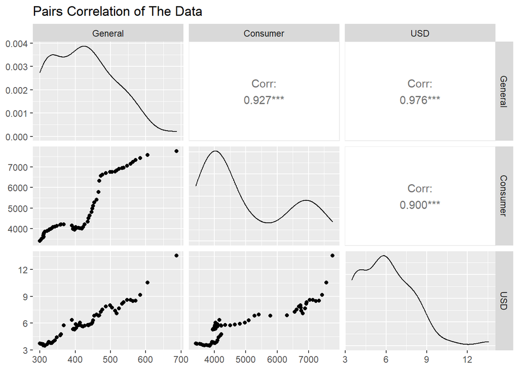

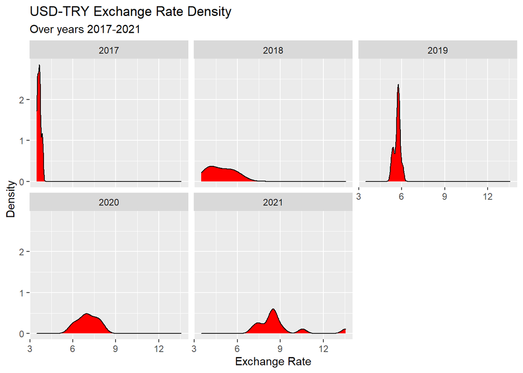

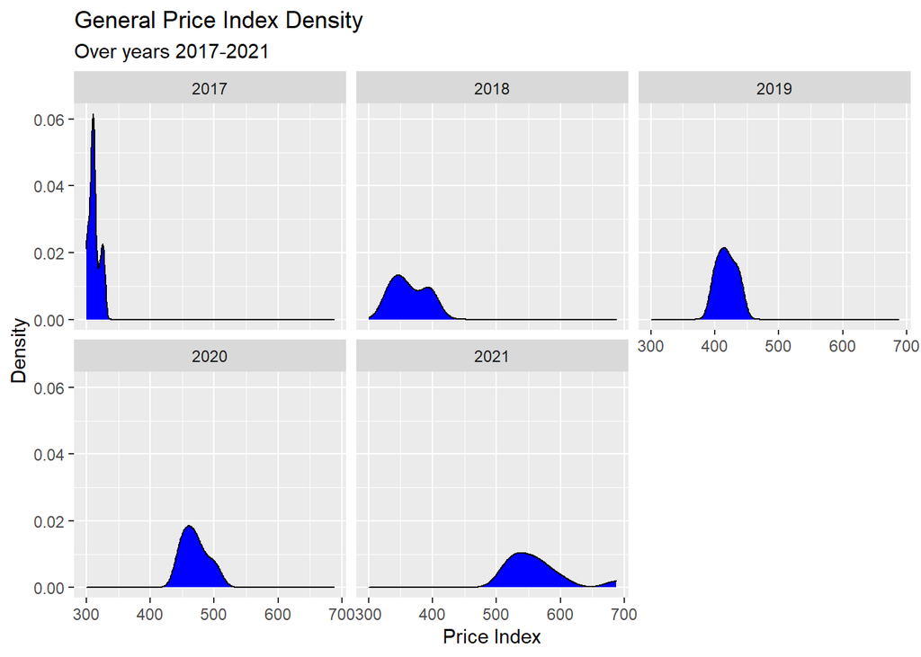

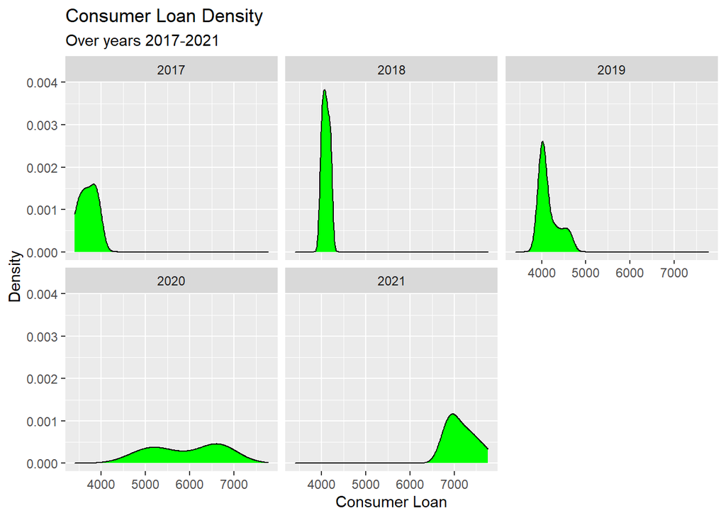

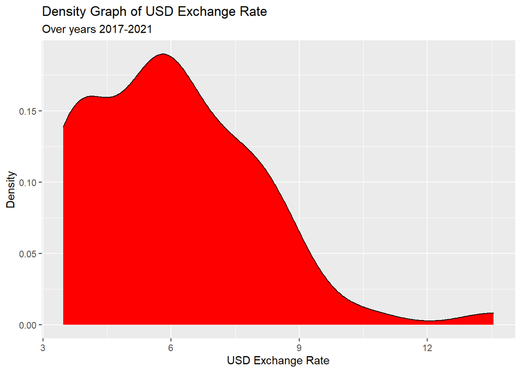

```
## [1] "Mean USD exchange rate:  6.0063267973628"
```

```
## [1] "Variance of USD exchange rate:  4.08399908669775"
```

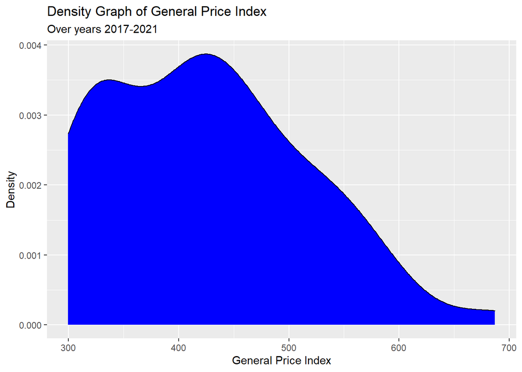

```
## [1] "Mean general price index:  424.942"
```

```
## [1] "Variance of general price index:  8264.70451118644"
```

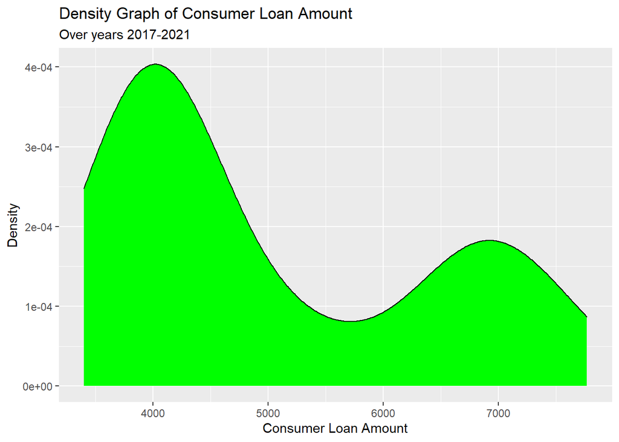

```
## [1] "Mean consumer loan amount:  5006.700019"
```

```
## [1] "Variance of consumer loan amount:  1921268.40920461"
```

# Normalized Data

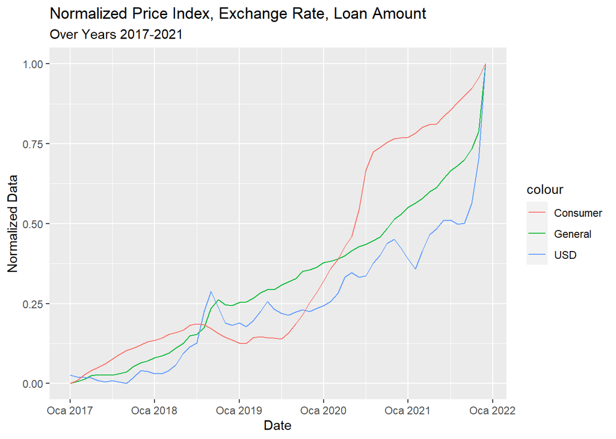

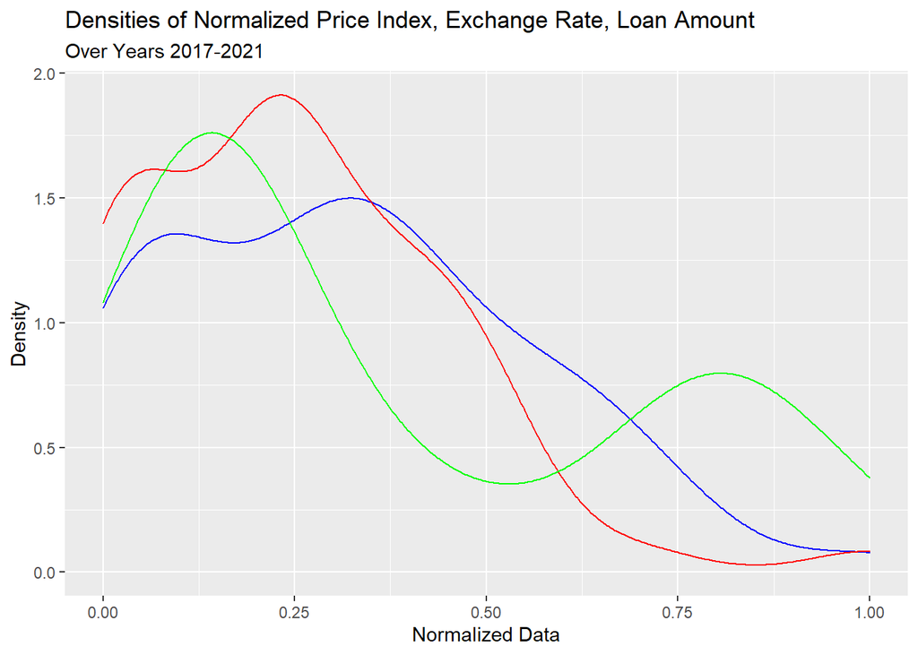

# Comparison

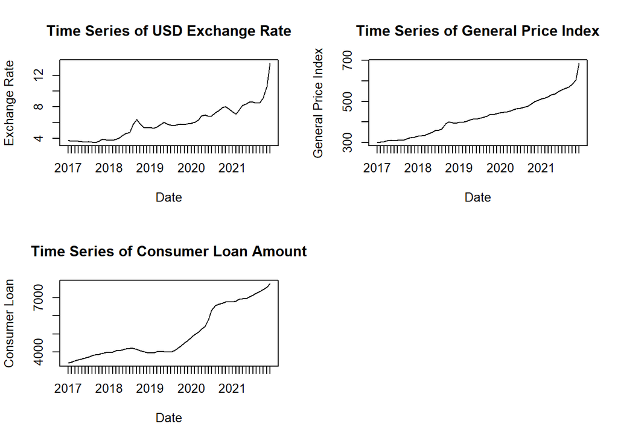

#Search Trends

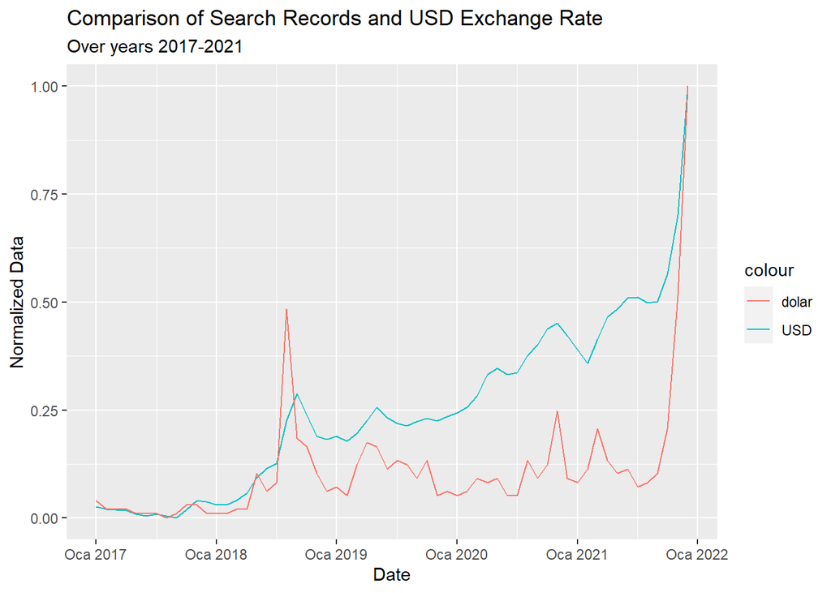

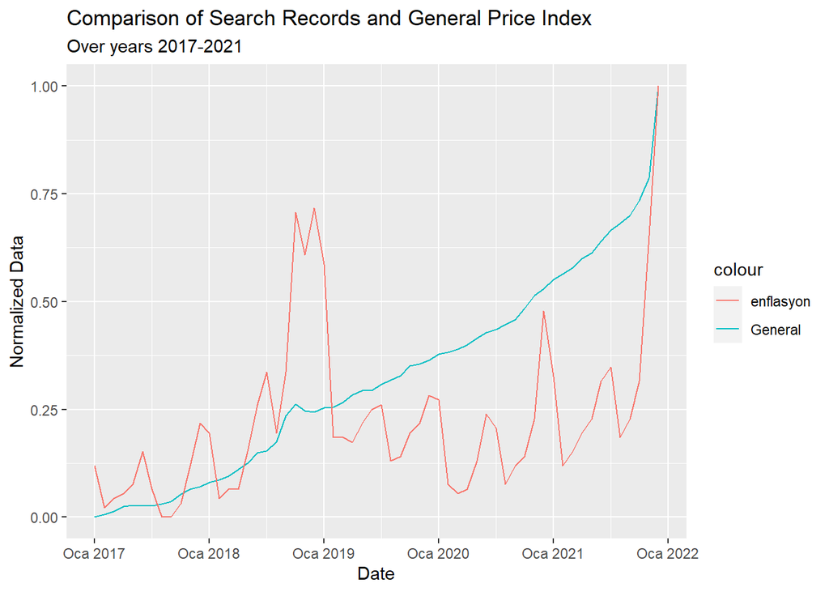

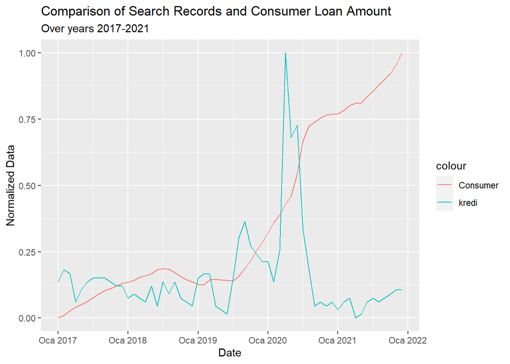

```
## [1] "Correlation between search records and data:"
```

```
## [1] "For Exchange Rate:  0.700347311935458"
```

```
## [1] "For Price Index:  0.471323849807394"
```

```
## [1] "For Loan Amount:  -0.0592550885033537"
```

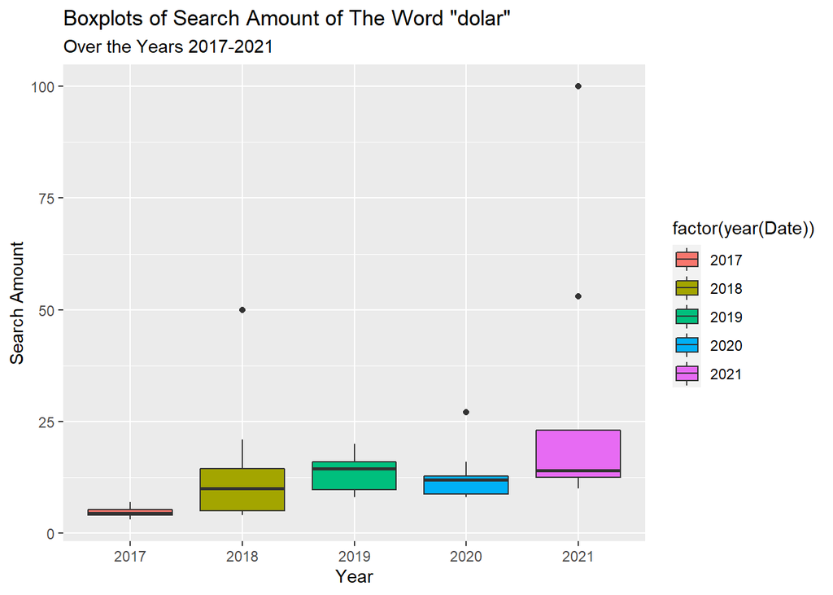

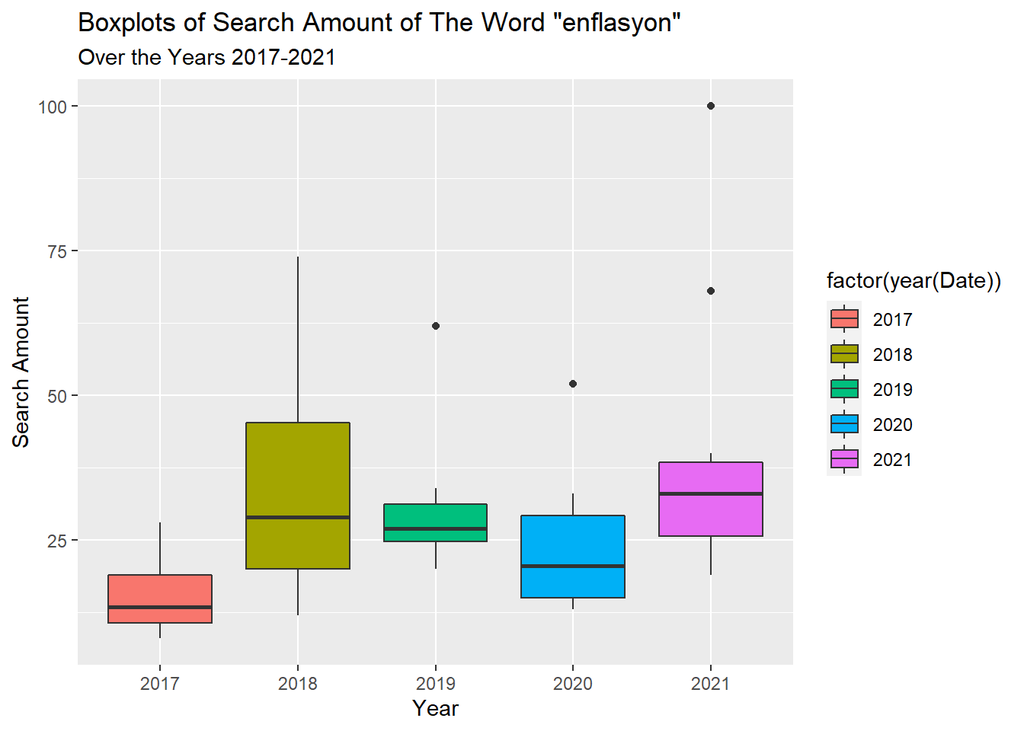

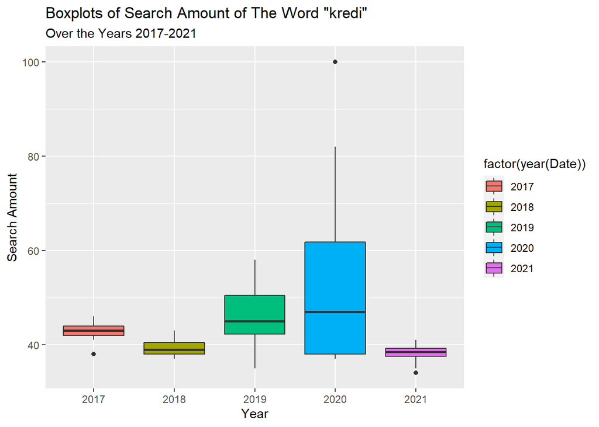